# scRNA-seq data analysis report_CC_sc01_01

Chang Yin

2025-03-13

## Datasets information

In this analysis, original row counts matrix are come from the mapping and counting results by using the 10X Genomics cellranger tools. Including: * Control * mud * nanobody

## Quality Control Process

1. Genes/cell > 500 genes
2. UMIs/cell > 1000 counts
3. log(genes)/log(UMIs) > 0.8
4. Mitochondrial genes proportion <= 18%
5. Ribosomal genes proportion >= 5% & =< 40%
6. Heat shock genes proportion <= 5%
7. Only keep genes have UMIs >= 2
8. Only keep genes at least express in 2 cells
9. Remove doublets

```r
seurat_control_singlet <- readRDS("/home/rstudio/Projects/Clemens_sc_202502/Outputs/seurat_control_singlet.rds")
seurat_mud_singlet <- readRDS("/home/rstudio/Projects/Clemens_sc_202502/Outputs/seurat_mud_singlet.rds")
seurat_nanobody_singlet <- readRDS("/home/rstudio/Projects/Clemens_sc_202502/Outputs/seurat_nanobody_singlet.rds")
```

```r
library(Seurat)
```

## Final Outputs after QC

#### control

For the control dataset: after the qc filtering, it remains 10,202 genes and 13,475 single cells

```r
dim(seurat_control_singlet)
```

```
## [1] 10202 13475
```

clustering into 34 clusters: c0-c33

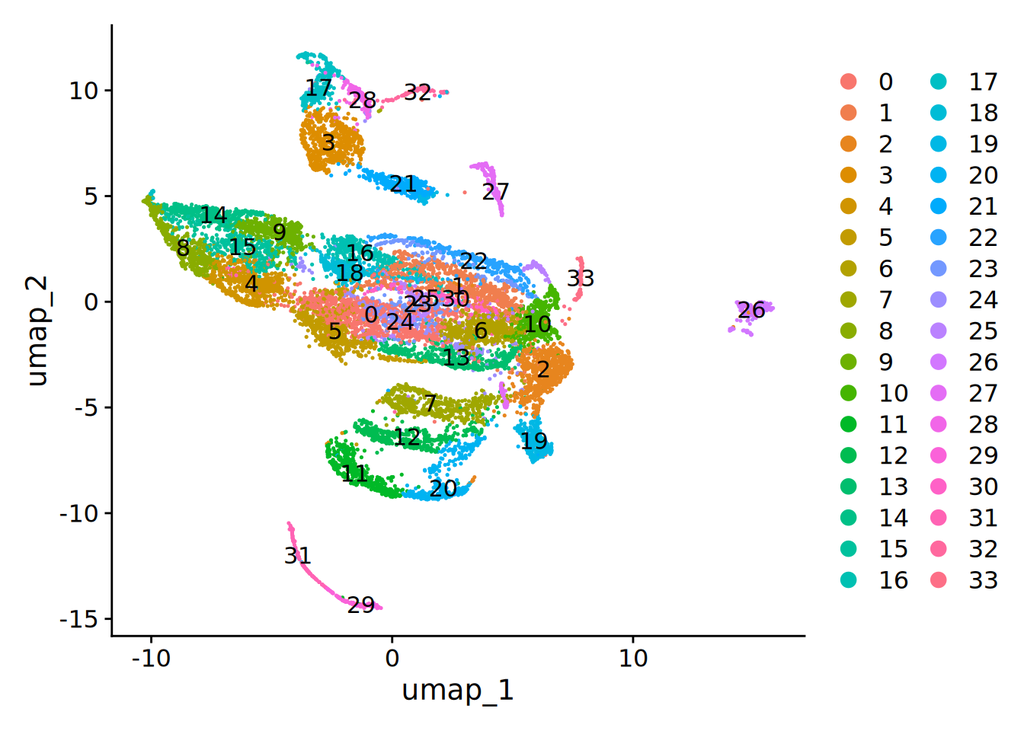

```r
DimPlot(seurat_control_singlet, reduction = "umap", label = TRUE)
```

some genes expression patterns

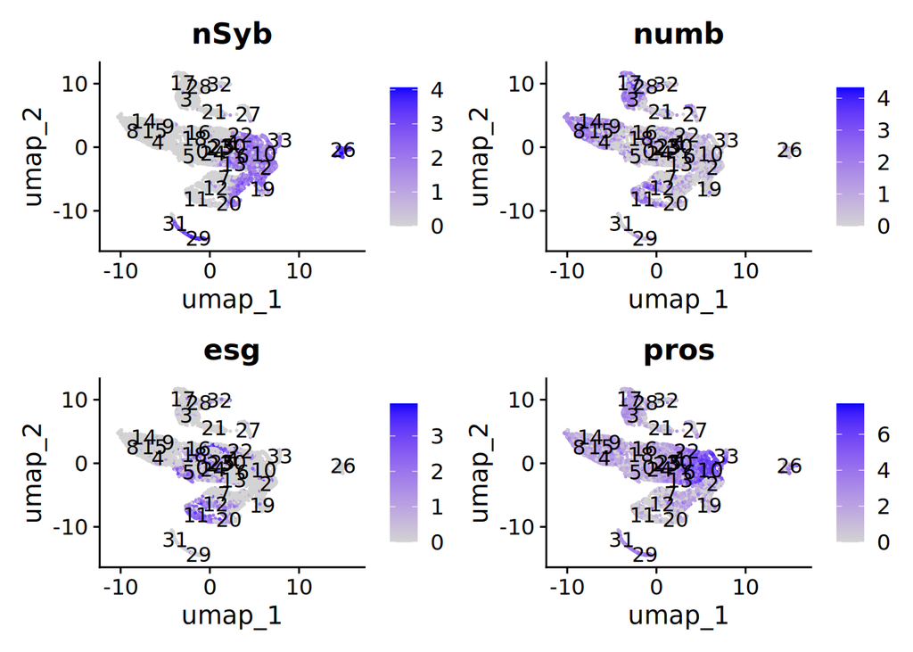

```r
FeaturePlot(seurat_control_singlet, features = c("nSyb", "numb", "esg", "pros"), label = TRUE)
```

#### mud

For the mud dataset: after the qc filtering, it remains 10,375 genes and 13,914 single cells

```r
dim(seurat_mud_singlet)
```

```
## [1] 10375 13914
```

clustering into 35 clusters: c0-c34

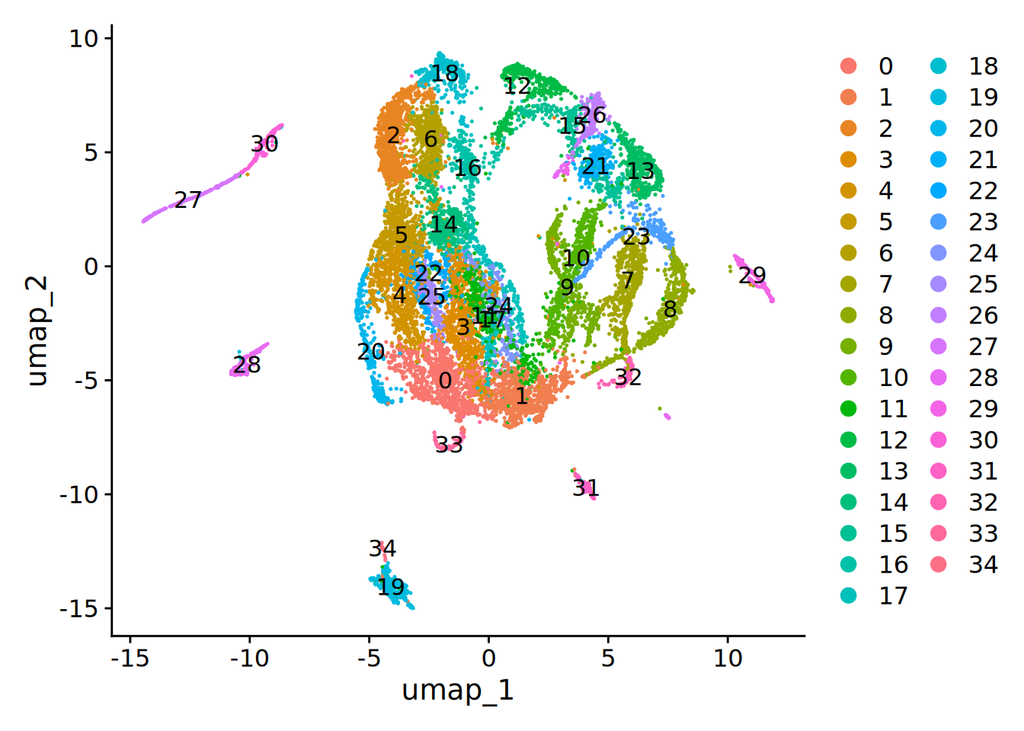

```r
DimPlot(seurat_mud_singlet, reduction = "umap", label = TRUE)
```

some genes expression patterns

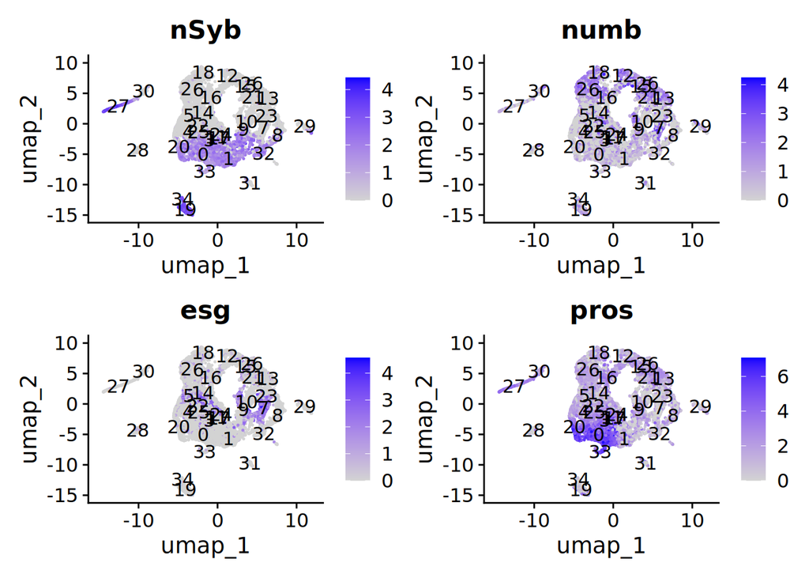

```r
FeaturePlot(seurat_mud_singlet, features = c("nSyb", "numb", "esg", "pros"), label = TRUE)
```

#### nanobody

For the nanobody dataset: after the qc filtering, it remains 10,366 genes and 13,262 single cells

```r
dim(seurat_nanobody_singlet)
```

```
## [1] 10366 13262
```

clustering into 35 clusters: c0-c34

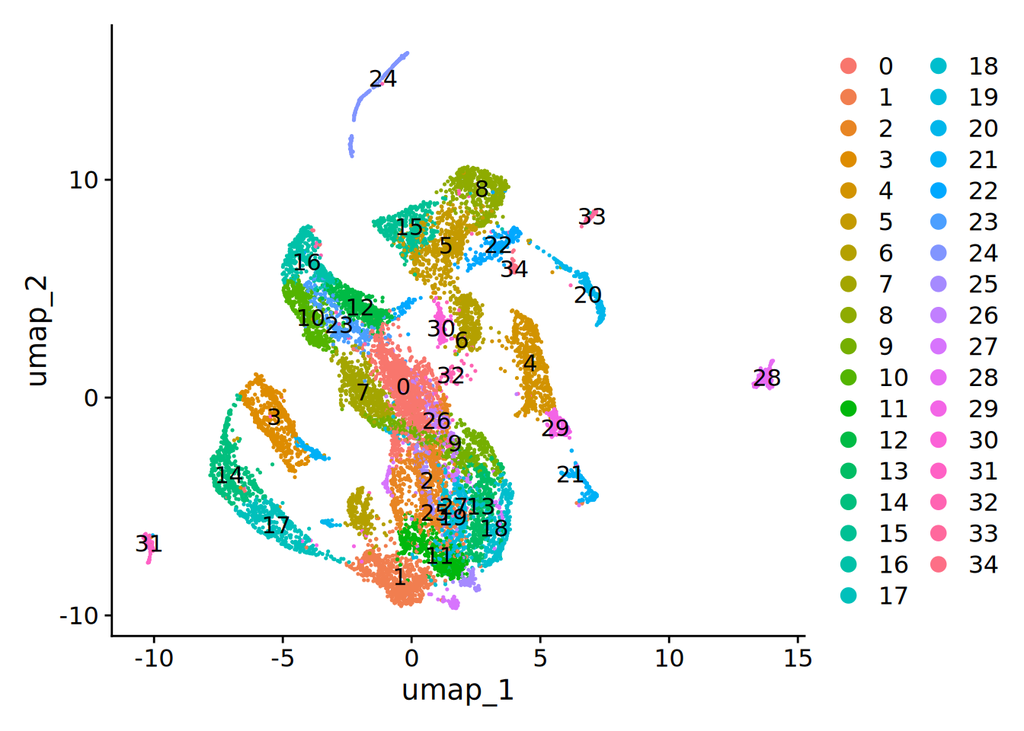

```r
DimPlot(seurat_nanobody_singlet, reduction = "umap", label = TRUE)
```

some genes expression patterns

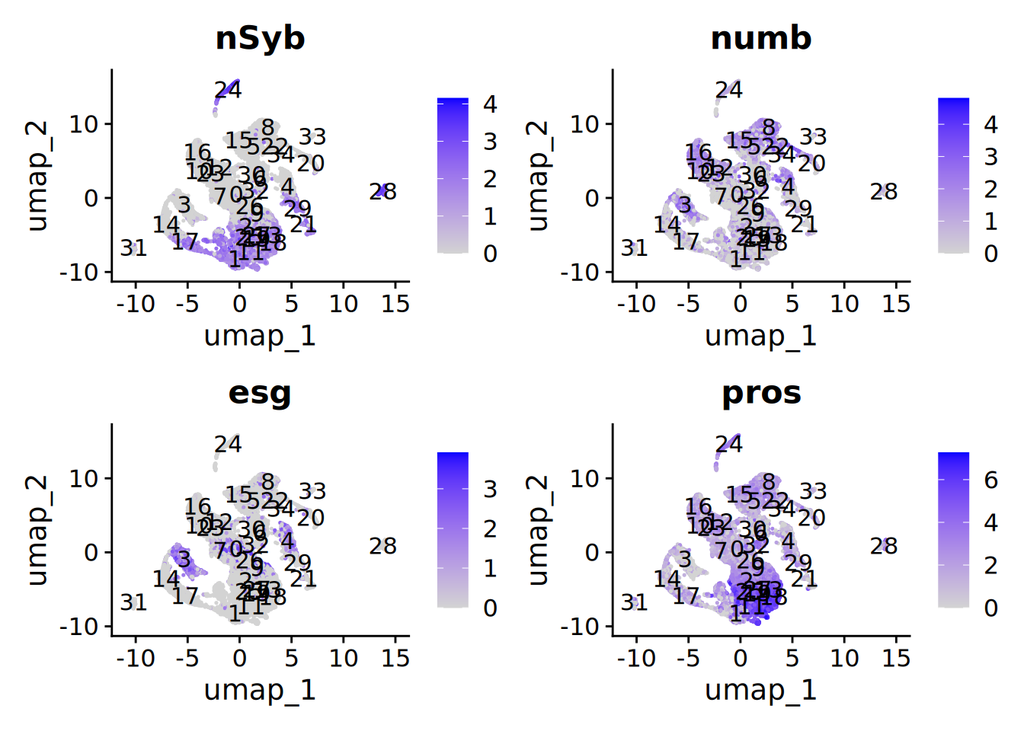

```r
FeaturePlot(seurat_nanobody_singlet, features = c("nSyb", "numb", "esg", "pros"), label = TRUE)
```

### Next Steps:

1. Annotation:
- Please review the marker gene list, highlight the genes that are highly interested in or highly related.
- Any other marker genes based on publications and references
2. cell-cycle analysis
- current gene list related to cell cycle
- any other genes need to be added
3. Differentially expressed genes identification
- Integrate 3 datasets
- Perform the DE analysis
  - control vs. mud
  - control vs. nanobody
4. Pseudotime analysis